# Patterns in Support for Reparations

About half of Americans either support or are not sure if they support the US government giving financial compensation to the descendants of enslaved people. While a majority of white people oppose reparations, a majority of Black Americans and a thin plurality of Hispanic people support them. Furthermore, a majority of Americans who acknowledge lasting effects of slavery and discrimination on Black Americans support reparations, while those that deny this reality oppose reparations by an overwhelming majority. Together, these patterns suggest that the appetite for reparations is significant and large groups of Americans support to the financial compensation of enslaved people.

## Disclaimer

The data for this project comes from a multi-wave survey project I conducted while at YouGov. When I left, I was allowed to take the data, graphics, and write-ups I had worked on to further analyze the data and post it here on my own website. *All of the views expressed in this post are my own*. They do not reflect the views or opinions of YouGov.

## Half of Americans Are Open To Reparations

While at YouGov, I fielded three waves of a national survey between December 2020 and June 2021 to gauge Americans’ awareness of systemic racism and the level of support for policies that aim to promote racial equity.

This sample has a combined N of a unique 2,700 respondents. It was weighted to be nationally representative on age, gender, race, education, census region, voter registration, news interest, and 2016 presidential vote. Weights ranged from 0.03 to 6.02, with a mean of 1, SD of 0.83 and a MOE of +/- 2.45 percent. All graphics and tables incorporate these weights.

In this survey, I asked respondents about their view on reparations for slavery. I chose to explicitly gauge support for reparations given to the descendents of enslaved people rather than asking about reparations for both slavery and centuries of discriminatory policy. Were I to run this again, I would like to adjust the wording to see how such a change would affect the patterns of support discussed in the remainder of this post.

```
Would you support the United States giving financial compensation to the individual descendants of enslaved people?
 <1> Strongly support
 <2> Somewhat support
 <3> Somewhat oppose
 <4> Strongly oppose
 <5> Not sure
```

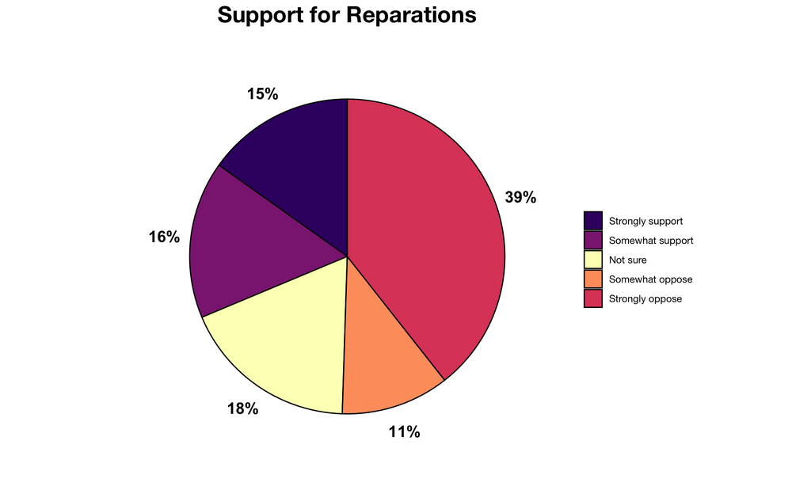

Overall, about half of Americans oppose reparations, while a little over 31 percent support them and 18 percent are not sure. The large level of uncertainty is likely in part due to the question’s design. I was attempting to ascertain general attitudes towards reparations for slavery as a concept rather than to measure support for a specific plan or for the term “Reparations” itself. Perhaps, the large level of uncertainty suggests that a significant percent of Americans are open to reparations but would need more details as to how they would be structured. And while a plurality of people do oppose reparations, about half of Americans are not opposed to them. And a closer look at the data reveals some illuminating patterns.

## Pluralities of Black and Hispanic People Support Reparations

Patterns of support for reparations differ significantly across racial groups. Overall, a plurality of about 43 percent of People of Color support reparations, while a majority of 61 percent of white people oppose them. Within People of Color, sixty percent of Black Americans support reparations, and only 19 percent oppose them. Support among Hispanic Americans is more split. A thin plurality supports reparations, but about equally as many oppose them or are not sure about them. And unfortunately, the confidence intervals on these values are fairly large.

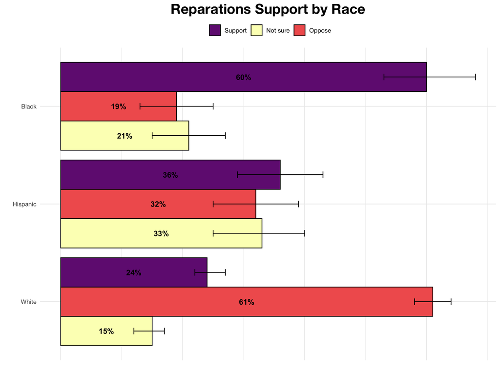

There is insufficient data to determine how these patterns manifest among other groups of People of Color, but this data suggests that white Americans’ majority opposition to reparations is somewhat anomalous and is a significant factor in explaining why half of Americans oppose reparations.

It is not a coincidence that those who have benefited most from America’s biased institutions are most likely to oppose actions that attempt to begin to make amends for it’s country’s history of oppression. Perhaps many white respondents are not aware of the ramifications of slavery and the degree to which the systems born out of it still influence life in America. Perhaps others are aware of these realities, but do not believe reparations, as described in the question, would be helpful. And finally some may not wish to attempt to address the lasting impacts of slavery and racial discrimination at all. It is difficult to know respondent’s rationals, but responses to a question aimed to measure awareness the effects of slavery and discrimination provide us with some clues.

## Reparations are Supported by a Majority of those with an Understanding of the Generational Effects of Slavery and Discrimination

In the same survey, respondents were asked to indicate the degree to which they agreed with the following statement:

```
Generations of slavery and discrimination have created conditions that make it difficult for African Americans to achieve economic mobility
```

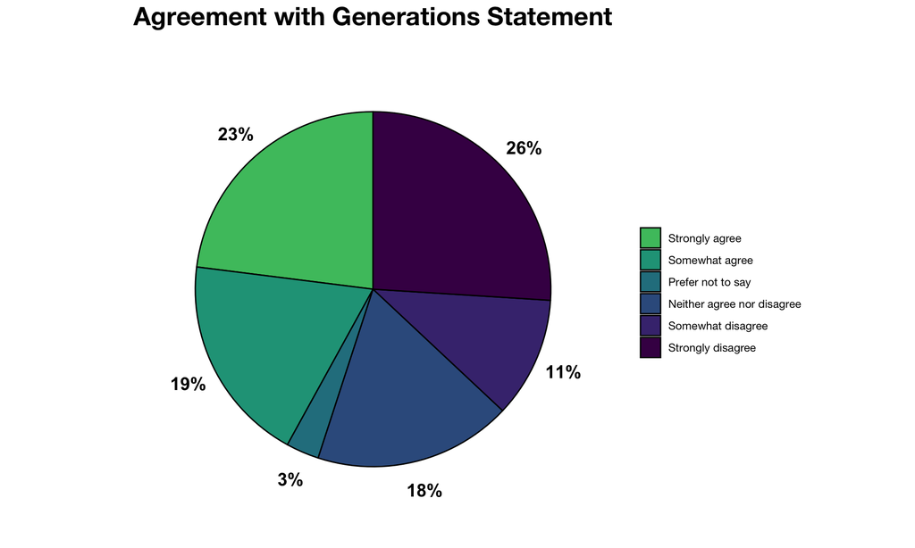

A plurality of Americans (about 43 percent) agree with the statement, and about 37 percent disagree with it. The majority of those who agree with the statement (55 percent) indicated support for reparations. Alternatively, a vast majority of those who disagree with the statement on the generational effects of slavery and discrimination (87 percent) oppose reparations. Only 25 percent of those who agree with the generational challenges of slavery oppose reperations, while 20 percent remain unsure.

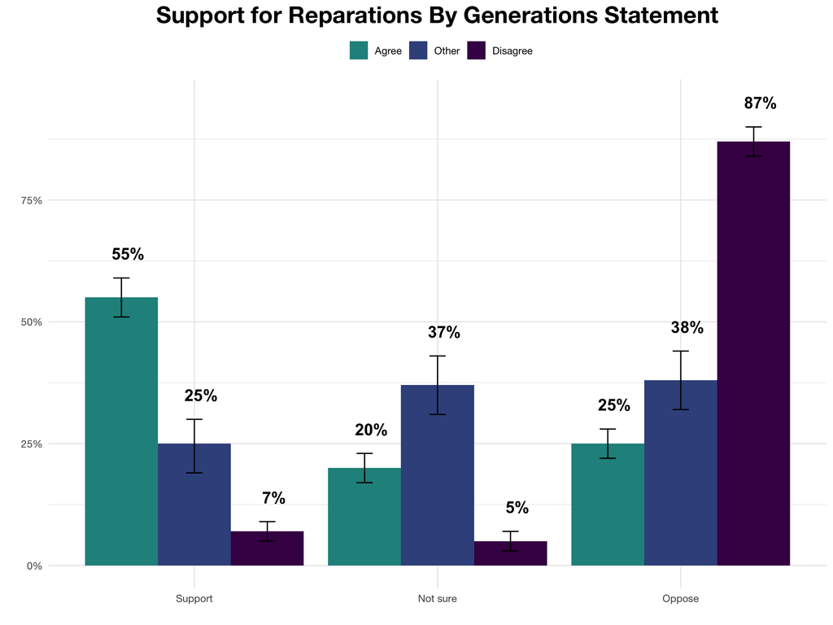

I believe this data reveals three patterns: (1) There is significant support for reparations for slavery among those who acknowledge the generational effects of slavery and discrimination on Black Americans. (2) Those who refuse to acknowledge the generational effects of slavery and discrimination oppose reparations in great numbers. There is very little uncertainty among this group, even though the description of compensation used in the question was vague. (3) Many of those who do not disagree with the generations statement are not sure as to whether or not they support reparations in the manner described in the question.

I think that most Americans who are able to admit that slavery has lead to generations of sytemic discrimination are ready to consider reparations and unpack what they might look like. Scholars and activists are offering concrete plans and there is a bill in Congress to establish a Commision to look into reparations called H.R. 40. Unfortunately, relatively few people are aware of it.

**Awareness of HR40 by Support for Reparations**

| Support for Reparations | Aware of HR40 Yes | Aware of HR40 No |
| --- | --- | --- |
| Support | 23% | 77% |
| Oppose | 14% | 86% |
| Not sure | 8% | 92% |
| All | 16% | 84% |

## Looking Forward

I hope that this project helps reinforce the reality that there is a significant appetite for reparations. It is not an exhaustive study and there are many ways that a survey like this could be tweaked, amended and re-run to more deeply explore people’s opinions on reparations. For example, I would like to test different wordings for the question that measures an individual’s opinions on reparations. In particular, I would like to see how support levels fluctuate for specific plans in order to ascertain which elements of reparations are most appealing to groups of people.

Yet, I do believe the patterns discussed in this post alone are compelling and I hope that discussions like this one can help focus dialogue on reparations and apply pressure to pass HR 40 and make reparations for slavery and disicrimination a priority.